# Census Data Analysis - Draft

Brian Bartley

8/18/2021

## Introduction to the data.

This data is from the 2019 5 year [American Community Survey (ACS)](https://www.census.gov/programs-surveys/acs/) administered by the U.S. Census Bureau. It is the same data set that underpins the [King County Census Viewer](https://kingcounty.maps.arcgis.com/apps/webappviewer/index.html?id=70a97e804e9b4991846cda2242985272) and [EJSCREEN](https://ejscreen.epa.gov/mapper/). The ACS is a very robust data with 27040 variables that can help answer a wide variety of research questions.

```
## # A tibble: 6 x 5
##         GEOID NAME                                       variable estimate   moe
##         <dbl> <chr>                                      <chr>       <dbl> <dbl>
## 1 53033011300 Census Tract 113, King County, Washington  medInc      56402  6661
## 2 53033004900 Census Tract 49, King County, Washington   medInc     101203 15043
## 3 53033026801 Census Tract 268.01, King County, Washing~ medInc      55761 10064
## 4 53033006400 Census Tract 64, King County, Washington   medInc     166125 18242
## 5 53033005100 Census Tract 51, King County, Washington   medInc     119625 24535
## 6 53033002000 Census Tract 20, King County, Washington   medInc     121184 15236
```

I estimated neighborhood common names by comparing a map of census tract outlines to maps.google.com. I did this for the census tracts surrounding KICA. As you can see census tracts do not lineup with community boarders. They are designed to contain 2,500 to 8,000 people and roughly align with community boundaries. That said they are semi permanent definitions that do not align with common community delineations. Hover your mouse over the area to see the community name I entered. Let me know if I got any of community names wrong and I can change them.

[interactive chart not shown]

## Median Income

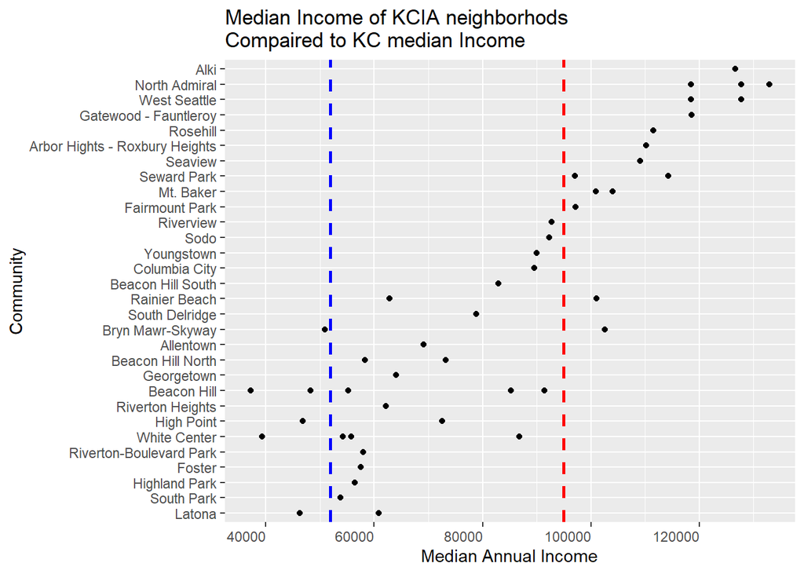

The map of the difference between the community median income and King County’s median income clearly shows where these lower income neighborhoods are clustered.

[interactive chart not shown]

Apart from looking at the median income communities we can also analyze income by looking a the proportion o f the community who’s family income is ***less than 200% of the federal poverty level**. It’s important to note that there is **considerable variability in this variable** because the poverty level is **determined by both household income and size**. As such, this map should only be used as a first order approximation of the distribution of poverty around KCIA.

[interactive chart not shown]

## Health Information

When considering the which communities are most effected by the airport it is important to think about how our operations effect community health outcomes. Though the census does not specifically track health metrics we can look at the populations that are most impacted by airport operation. According the medical experts individuals under 5 years old are at risk of developing asthma and other long term health outcomes from particulates and emissions associated with aircraft/airfields.

[interactive chart not shown]

## Race and Ethinicity

The census excels at providing race and ethnicity information. There are several layers that we can analyse. Singe race identity, intersections of two or more racial identities and country of origin. For simplicity I’m representing people of color as anyone that does not identify as White or Hispanic.

[interactive chart not shown]

Here is bar graph of the 8 communities that surround KCIA. The racial identity breakdown of King County, the left most item in the bar chart, is more white than most of the communities that surround KCIA.

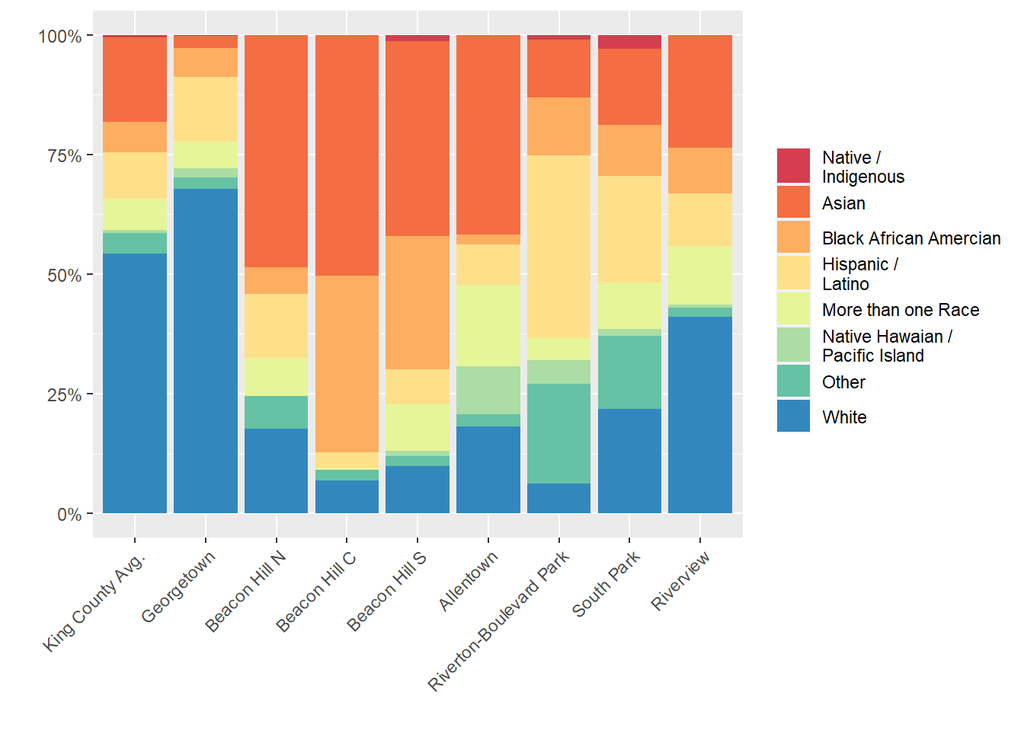

## Language

One interesting thing that the ACS tracks is the language that individuals speak at home, the proportion of people who speak English “less than very well”, and the language that people who speak English “less than very well” speak at home.

[interactive chart not shown]

It’s clear the population of people who speak English less than well are concentrated north east and south west of KCIA. It may be useful to concentrate our non-English language outreach based on the distribution of langues spoken at home. For communities to the north east of KCIA the most common language spoken by people with limited English skills is Chinese. Unfortunately the ACS does not distinguish between mandarin and other Chinese languages.

[interactive chart not shown]

Spanish is the primary language south and west of KCIA.

[interactive chart not shown]

## Occupation

The ACS also tracks employment statistics for working age adults. When looking to target subcontractors from the communities around KCIA it may be useful target **Allentown** or **Rivertown-Boulevard Park** where more people employed in construction. This graph includes all occupation sectors in the 8 communities near KCIA that employ 5% or more of the population.

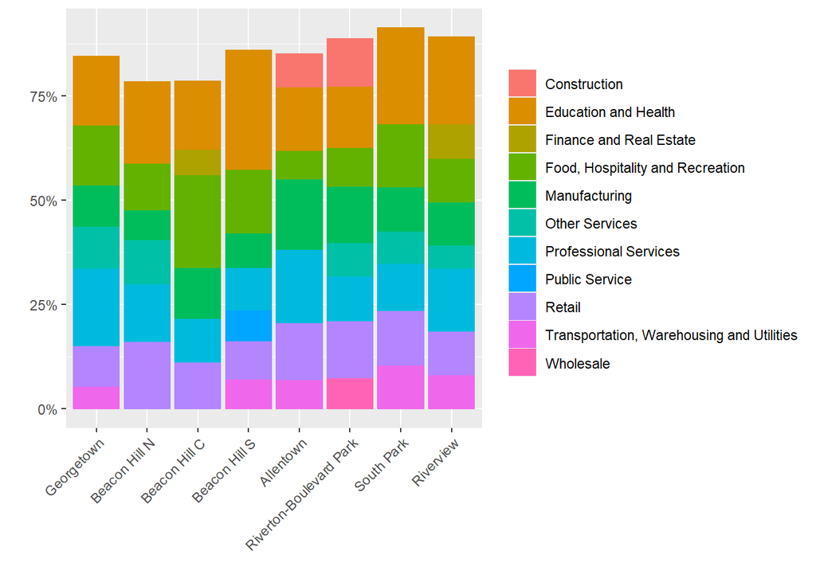